# PCIT-CoS-Waitlist RCT Paper 1: DERS Total

Nancy Briggs

2024-04-29

Reverse scored items corrected by :

Reverse = (-1*ders) + (5 + 1)

### DERS Total

Output run on 2024-04-29

Values have been calculated by: - sum computed from a sum of all items. - Reverse-scored items 1, 2, 6, 7, 8, 10, 17, 20, 22, 24 and 34.

Higher scores suggest greater problems with emotion regulation.

ID12 had a value of 14 for `fu_ders13`. It has been fixed to 1.

#### Descriptives

| group | time | n | mean | sd | median | min | max |
| --- | --- | --- | --- | --- | --- | --- | --- |
| 1 | 1 | 30 | 71.333 | 19.683 | 67 | 45 | 135 |
| 1 | 2 | 23 | 69.652 | 17.137 | 65 | 43 | 106 |
| 1 | 3 | 18 | 67.611 | 22.656 | 63 | 21 | 117 |
| 2 | 1 | 28 | 77.179 | 26.238 | 76 | 44 | 162 |
| 2 | 2 | 13 | 85.923 | 21.286 | 96 | 48 | 114 |
| 2 | 3 | 5 | 72.200 | 19.791 | 75 | 52 | 98 |
| 3 | 1 | 26 | 78.731 | 23.156 | 76 | 43 | 137 |
| 3 | 2 | 22 | 75.409 | 21.102 | 76 | 40 | 136 |
| 3 | 3 | 0 | NaN | NA | NA | Inf | -Inf |

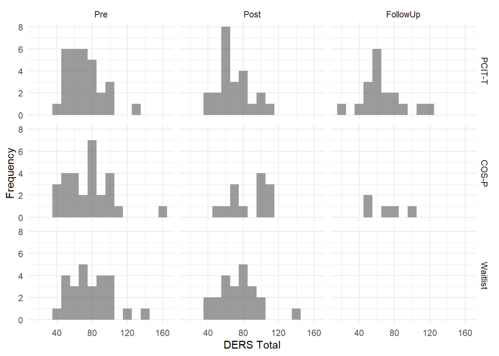

#### Model & Results

A linear mixed model with random effect for individual and fixed effects of group, time and the interaction was run. Estimated marginal means were obtained, and contrasts specified to test Hypothesis 1 and Hypothesis 2.

```
## fixed-effect model matrix is rank deficient so dropping 1 column / coefficient
```

```
## refitting model(s) with ML (instead of REML)
```

|  | Effect | npar | AIC | BIC | logLik | deviance | Chisq | Df | Pr(>Chisq) |
| --- | --- | --- | --- | --- | --- | --- | --- | --- | --- |
| result0 | Intercept | 3 | 1427.245 | 1436.563 | -710.623 | 1421.245 | NA | NA | NA |
| result1 | Group | 5 | 1429.019 | 1444.549 | -709.510 | 1419.019 | 2.226 | 2 | 0.329 |
| result2 | Time | 7 | 1430.301 | 1452.043 | -708.151 | 1416.301 | 2.718 | 2 | 0.257 |
| result3 | Group*Time | 10 | 1431.465 | 1462.524 | -705.732 | 1411.465 | 4.836 | 3 | 0.184 |

This is the ANOVA table for the model. p-values are likelihood ratio tests for adding the new term to the model just before. A p-value <0.05 indicates that adding that term results in better model fit. The most important p-value is the interaction p-value. Here, there is no evidence that the pattern of change over time is different among the groups (p=0.184).

```r
summary(result3)
```

```
## Linear mixed model fit by REML. t-tests use Satterthwaite's method [
## lmerModLmerTest]
## Formula: outcome ~ group * time + (1 | id)
##    Data: dat
##
## REML criterion at convergence: 1375.4
##
## Scaled residuals:
##     Min      1Q  Median      3Q     Max
## -3.1632 -0.3982 -0.0207  0.3572  2.3905
##
## Random effects:
##  Groups   Name        Variance Std.Dev.
##  id       (Intercept) 420.5    20.51
##  Residual             110.2    10.50
## Number of obs: 165, groups:  id, 85
##
## Fixed effects:
##              Estimate Std. Error      df t value Pr(>|t|)
## (Intercept)   71.3333     4.2062 92.5007  16.959   <2e-16 ***
## group2         5.8452     6.0537 92.5007   0.966    0.337
## group3         7.8918     6.1345 93.6740   1.286    0.201
## time2         -0.7542     3.0472 74.0792  -0.248    0.805
## time3         -4.6866     3.3483 74.6643  -1.400    0.166
## group2:time2   5.0694     5.0302 77.5071   1.008    0.317
## group3:time2  -5.6953     4.4169 74.4210  -1.289    0.201
## group2:time3   4.6025     6.8407 77.4766   0.673    0.503
## ---
## Signif. codes:  0 '***' 0.001 '**' 0.01 '*' 0.05 '.' 0.1 ' ' 1
##
## Correlation of Fixed Effects:
##             (Intr) group2 group3 time2  time3  grp2:2 grp3:2
## group2      -0.695
## group3      -0.686  0.476
## time2       -0.287  0.199  0.197
## time3       -0.261  0.181  0.179  0.427
## group2:tim2  0.174 -0.250 -0.119 -0.606 -0.259
## group3:tim2  0.198 -0.137 -0.299 -0.690 -0.295  0.418
## group2:tim3  0.128 -0.184 -0.088 -0.209 -0.489  0.346  0.144
## fit warnings:
## fixed-effect model matrix is rank deficient so dropping 1 column / coefficient
```

#### Estimated Means & Change

Estimated means for each Treatment and Time are presented. In addition, within-group change between time points is presented with 95% CIs.

##### Group mean difference at each timepoint

NO BOOTSTRAPPING DONE

Effect sizes all calculated by the pooled T1 SD of the outcome. Adjusted p-value from Bonferroni correction.

Group Differences at Each Time Point

| Group Difference | Time | Mean | SE | t | p | adj p | Lower CL | Upper CL | Effect Size | Lower CL | Upper CL |
| --- | --- | --- | --- | --- | --- | --- | --- | --- | --- | --- | --- |
| 1 - 2 | 1 | -5.845 | 6.054 | -0.966 | 0.600 | 1.000 | -20.255 | 8.565 | -0.253 | -0.647 | 0.230 |
| 1 - 3 | 1 | -7.892 | 6.135 | -1.286 | 0.406 | 0.604 | -22.492 | 6.708 | -0.342 | -0.656 | -0.039 |
| 2 - 3 | 1 | -2.047 | 6.237 | -0.328 | 0.942 | 1.000 | -16.890 | 12.797 | -0.089 | -0.398 | 0.141 |
| 1 - 2 | 2 | -10.915 | 6.843 | -1.595 | 0.251 | 0.339 | -27.136 | 5.307 | -0.473 | -0.737 | -0.239 |
| 1 - 3 | 2 | -2.197 | 6.402 | -0.343 | 0.937 | 1.000 | -17.407 | 13.014 | -0.095 | -0.571 | 0.138 |
| 2 - 3 | 2 | 8.718 | 6.966 | 1.252 | 0.425 | 0.639 | -7.798 | 25.235 | 0.378 | -0.272 | 0.673 |
| 1 - 2 | 3 | -10.448 | 8.271 | -1.263 | 0.418 | 0.625 | -30.018 | 9.123 | -0.453 | -0.899 | 0.132 |
| 1 - 3 | 3 | NA | NA | NA | NA | NA | NA | NA | NA | NA | NA |
| 2 - 3 | 3 | NA | NA | NA | NA | NA | NA | NA | NA | NA | NA |

##### Change within each group

Within-Group Change and Effect Sizes

| Change | Group | Mean | SE | t | p | adj p | Lower CL | Upper CL | Effect Size | Lower CL | Upper CL |
| --- | --- | --- | --- | --- | --- | --- | --- | --- | --- | --- | --- |
| 1 - 2 | 1 | 0.754 | 3.050 | 0.247 | 0.967 | 1.000 | -6.532 | 8.041 | 0.033 | -0.048 | 0.267 |
| 1 - 3 | 1 | 4.687 | 3.352 | 1.398 | 0.347 | 0.498 | -3.321 | 12.694 | 0.203 | 0.061 | 0.416 |
| 2 - 3 | 1 | 3.932 | 3.433 | 1.145 | 0.489 | 0.767 | -4.273 | 12.138 | 0.170 | -0.190 | 0.239 |
| 1 - 2 | 2 | -4.315 | 4.012 | -1.075 | 0.532 | 0.856 | -13.888 | 5.258 | -0.187 | -0.466 | 0.122 |
| 1 - 3 | 2 | 0.084 | 5.979 | 0.014 | 1.000 | 1.000 | -14.186 | 14.354 | 0.004 | -0.405 | 0.467 |
| 2 - 3 | 2 | 4.399 | 6.051 | 0.727 | 0.748 | 1.000 | -10.055 | 18.854 | 0.191 | -0.243 | 0.538 |
| 1 - 2 | 3 | 6.450 | 3.201 | 2.015 | 0.115 | 0.142 | -1.197 | 14.096 | 0.279 | 0.000 | 0.626 |
| 1 - 3 | 3 | NA | NA | NA | NA | NA | NA | NA | NA | NA | NA |
| 2 - 3 | 3 | NA | NA | NA | NA | NA | NA | NA | NA | NA | NA |

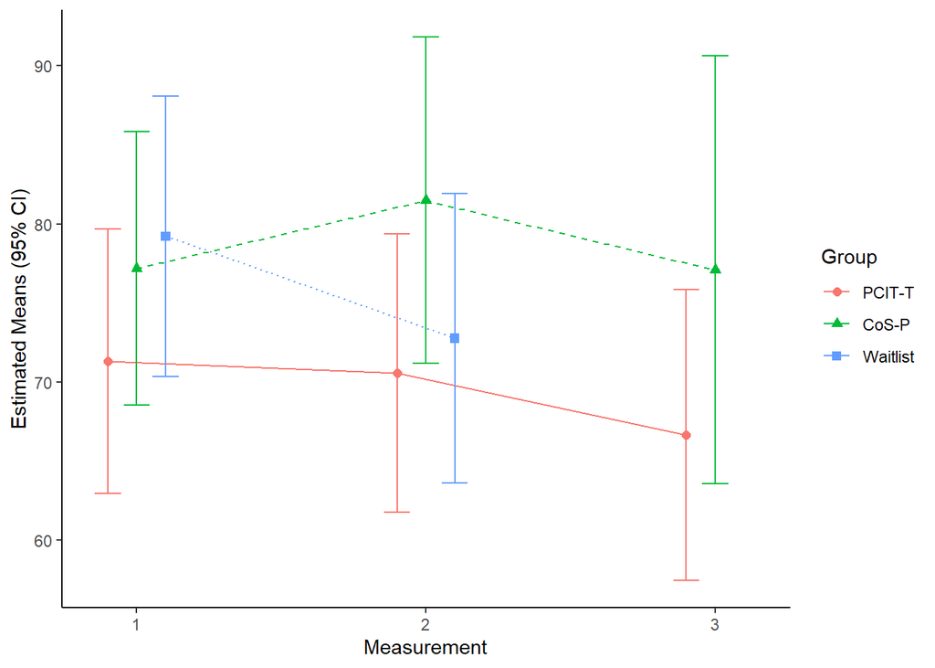

#### Hypothesis 1

We hypothesize that from baseline (‘T1’) to post-treatment/waitlist (‘T2’) there will be a gradient effect, whereby parent-child dyads who receive PCIT-T will show the greatest gains and parent-child dyads who receive no treatment will show the least gains. For the outcome, then, the null hypothesis is:

$H_0: \text {mean change}(\text{PCIT-T}) = \text {mean change}(\text{CoS-P}) = \text {mean change}(\text{Waitlist})$ $H_A: \text {mean change}(\text{PCIT-T}) > \text {mean change}(\text{CoS-P})$ $\&$ $\text {mean change}(\text{CoS-P}) > \text {mean change}(\text{Waitlist})$

For this, we test two tests, and then look at the magnitude of change within each group.

This is a joint hypothesis test.

First, confirming that the ordering of the means is as hypothesized:

```
## group = 1:
##  contrast estimate   SE   df t.ratio p.value
##  1 - 2      0.7542 3.05 78.4   0.247  0.9669
##  1 - 3      4.6866 3.35 79.0   1.398  0.3468
##  2 - 3      3.9323 3.43 76.8   1.145  0.4894
##
## group = 2:
##  contrast estimate   SE   df t.ratio p.value
##  1 - 2     -4.3151 4.01 83.9  -1.075  0.5319
##  1 - 3      0.0841 5.98 82.7   0.014  0.9999
##  2 - 3      4.3992 6.05 78.7   0.727  0.7482
##
## group = 3:
##  contrast estimate   SE   df t.ratio p.value
##  1 - 2      6.4495 3.20 79.0   2.015  0.1153
##  1 - 3      nonEst   NA   NA      NA      NA
##  2 - 3      nonEst   NA   NA      NA      NA
##
## Degrees-of-freedom method: kenward-roger
## P value adjustment: tukey method for comparing a family of 3 estimates
```

So, the gradient of change is NOT MET.

The p-value below only can be interpreted as a test of whether the change between G1 and G2 & between G2 & G3 is different, but not as supporting the order.

```
##   (Intercept) group2 group3 time2 time3 group2:time2 group3:time2 group2:time3
## 1           0      0      0     0     0           -1            0            0
## 2           0      0      0     0     1            0            1            0
```

```
##
##   General Linear Hypotheses
##
## Linear Hypotheses:
##        Estimate
## 1 == 0   -5.069
## 2 == 0  -10.382
##
## Global Test:
##       F DF1 DF2  Pr(>F)
## 1 3.579   2 155 0.03023
```

p=0.0302.

The p-value only can be interpreted as a test of whether the change between G1 and G2 & between G2 & G3 is different, but not as supporting the order.

#### Hypothesis 2

##### Change from T2-T3

There will be a gradient of size of change from T2 to T3 such that the change in the PCIT-T group > the change in the CoS-P group. This isn’t really a gradient; it’s just 1 hypothesis.

First, the change in PCITT and COSP from time 2 to time 3:

```
## group = 1:
##  time emmean   SE    df lower.CL upper.CL
##  1      71.3 4.21  96.6     63.0     79.7
##  2      70.6 4.43 112.5     61.8     79.4
##  3      66.6 4.65 126.9     57.5     75.8
##
## group = 2:
##  time emmean   SE    df lower.CL upper.CL
##  1      77.2 4.35  96.6     68.5     85.8
##  2      81.5 5.21 143.7     71.2     91.8
##  3      77.1 6.84 149.4     63.6     90.6
##
## group = 3:
##  time emmean   SE    df lower.CL upper.CL
##  1      79.2 4.47  98.8     70.4     88.1
##  2      72.8 4.62 109.0     63.6     81.9
##  3    nonEst   NA    NA       NA       NA
##
## Degrees-of-freedom method: kenward-roger
## Confidence level used: 0.95
```

```
## group = 1:
##  contrast estimate   SE   df lower.CL upper.CL
##  1 - 2      0.7542 3.05 78.4    -6.53     8.04
##  1 - 3      4.6866 3.35 79.0    -3.32    12.69
##  2 - 3      3.9323 3.43 76.8    -4.27    12.14
##
## group = 2:
##  contrast estimate   SE   df lower.CL upper.CL
##  1 - 2     -4.3151 4.01 83.9   -13.89     5.26
##  1 - 3      0.0841 5.98 82.7   -14.19    14.35
##  2 - 3      4.3992 6.05 78.7   -10.06    18.85
##
## group = 3:
##  contrast estimate   SE   df lower.CL upper.CL
##  1 - 2      6.4495 3.20 79.0    -1.20    14.10
##  1 - 3      nonEst   NA   NA       NA       NA
##  2 - 3      nonEst   NA   NA       NA       NA
##
## Degrees-of-freedom method: kenward-roger
## Confidence level used: 0.95
## Conf-level adjustment: tukey method for comparing a family of 3 estimates
```

```r
## Specify contrast matrices
# Hyp1 is 1 df test
# could use alternative="less" ir alternative="greater" in glht
hyp2   <- matrix(c(0, 0,0, 0,0, -1,0,1 ),1)
hyp2F <- glht(result3, linfct = hyp2)
summary(hyp2F)
```

```
##
##   Simultaneous Tests for General Linear Hypotheses
##
## Fit: lmer(formula = outcome ~ group * time + (1 | id), data = dat)
##
## Linear Hypotheses:
##        Estimate Std. Error z value Pr(>|z|)
## 1 == 0  -0.4669     6.9501  -0.067    0.946
## (Adjusted p values reported -- single-step method)
```

```r
s<-summary(hyp2F, test = Ftest())
#also see this webpage for more on contrasts https://rcompanion.org/rcompanion/h_01.html



## Extract pvaue for evidence / no evidence
evidence = ifelse(s$test$pvalue<0.05, "evidence", "no evidence")
```

Change in G1 from T2 to T3: 3.932

Change in G2 from T2 to T3: 4.399

##### Change from T1-T3

```
##
##   General Linear Hypotheses
##
## Linear Hypotheses:
##        Estimate
## 1 == 0    4.603
##
## Global Test:
##        F DF1 DF2 Pr(>F)
## 1 0.4527   1 155 0.5021
```

Change in G1 from T1 to T3: 4.687

Change in G2 from T1 to T3: 0.084

p=0.5021. We have no evidence that the change from T1 to T3 is different for G1 and G2

#### Residuals

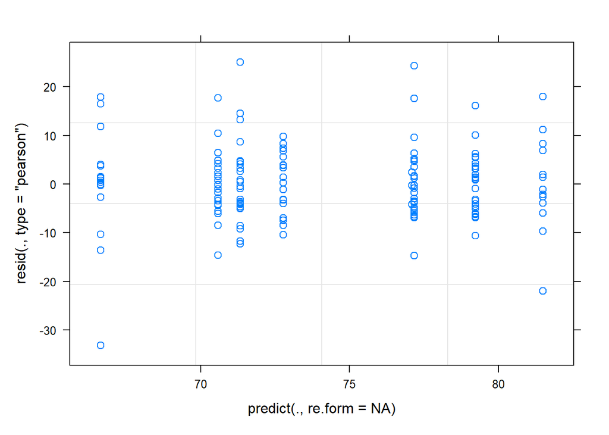

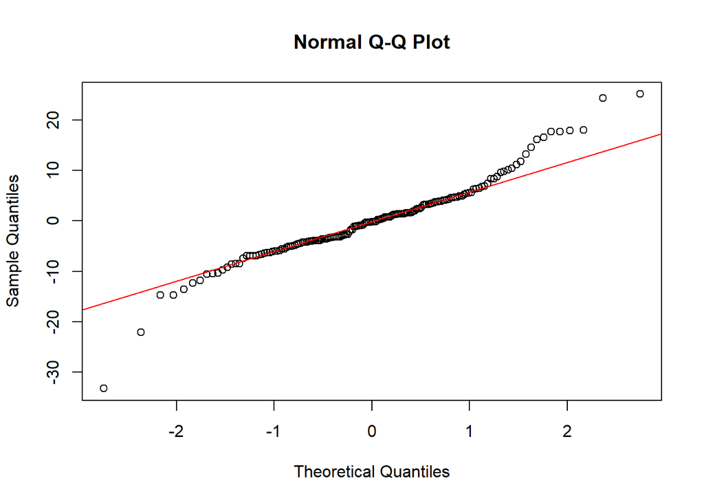

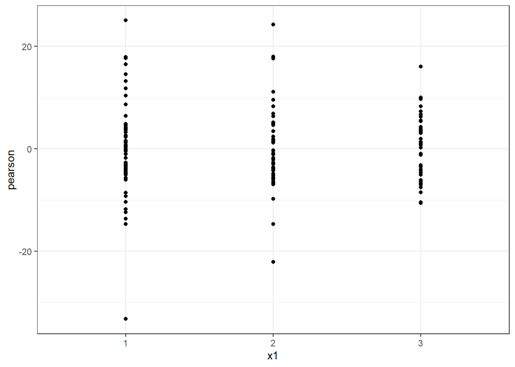

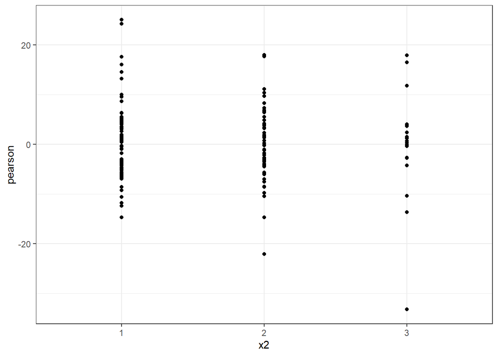

```r
rm(list = ls())
```